# R Notebook

This exercise covers sales and promotion data modelling, from the basic linear regression to mixed effects model. We will go over them one by one. Please note that here the data is hypothetical, and for academic use only. Due to copyright restriction I cannot share the datasets with anyone outside McCombs Business School.

Loading in sales data of a local store 50 weeks before and 50 weeks after the opening of a Walmart in the area.

```r
wm.dat = read.csv("Walmart_Data.csv", header = T)
str(wm.dat)
```

```
'data.frame':   100 obs. of  6 variables:
 $ week     : int  1 2 3 4 5 6 7 8 9 10 ...
 $ Sales    : int  586953 838022 861991 767198 777392 725924 701517 1027152 755625 445967 ...
 $ Promotion: num  0.89 1.08 0.95 1.06 1.01 1.07 1.22 1.06 1.08 0.8 ...
 $ Feature  : num  0.87 0.84 1.12 0.95 1.06 1.09 1.03 1.08 0.99 0.88 ...
 $ Walmart  : Factor w/ 2 levels "No","Present": 1 1 1 1 1 1 1 1 1 1 ...
 $ Holiday  : Factor w/ 2 levels "No","Yes": 1 1 1 1 1 1 1 1 1 1 ...
```

```r
summary(wm.dat)
```

```
      week            Sales           Promotion
 Min.   :  1.00   Min.   : 299359   Min.   :0.790
 1st Qu.: 25.75   1st Qu.: 512626   1st Qu.:0.940
 Median : 50.50   Median : 610754   Median :1.010
 Mean   : 50.50   Mean   : 644054   Mean   :1.011
 3rd Qu.: 75.25   3rd Qu.: 722809   3rd Qu.:1.062
 Max.   :100.00   Max.   :1267301   Max.   :1.330
    Feature         Walmart   Holiday
 Min.   :0.780   No     :50   No :92
 1st Qu.:0.940   Present:50   Yes: 8
 Median :1.015
 Mean   :1.007
 3rd Qu.:1.080
 Max.   :1.260
```

We will make a new variable called “logSales”, for a better linear fit.

```r
wm.dat$logSales = log(wm.dat$Sales)
```

To compute our first linear model, it is important to understand the correlation of each variable here - this is to include any interactions in our model later. The variables of “Sales”, “Promotion”, and “Feature” are stored in the 2,3,4th columns.

```r
cor(wm.dat[,2:4])
```

```
              Sales  Promotion    Feature
Sales     1.0000000 0.37739562 0.22438793
Promotion 0.3773956 1.00000000 0.06513678
Feature   0.2243879 0.06513678 1.00000000
```

Scatterplot of Sales and Promotion, and Sales and Feature:

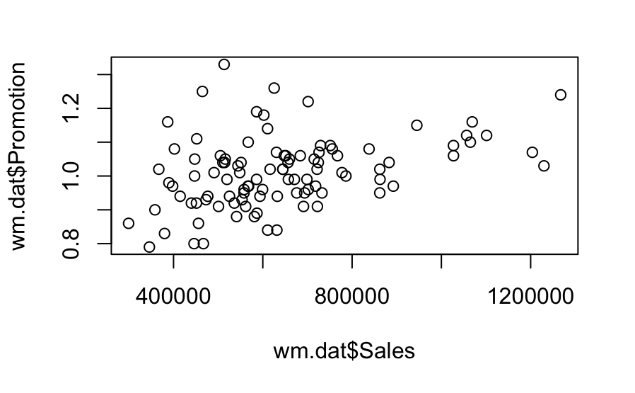

```r
plot(wm.dat$Sales,wm.dat$Promotion)
```

Similarly, for Sales and Feature

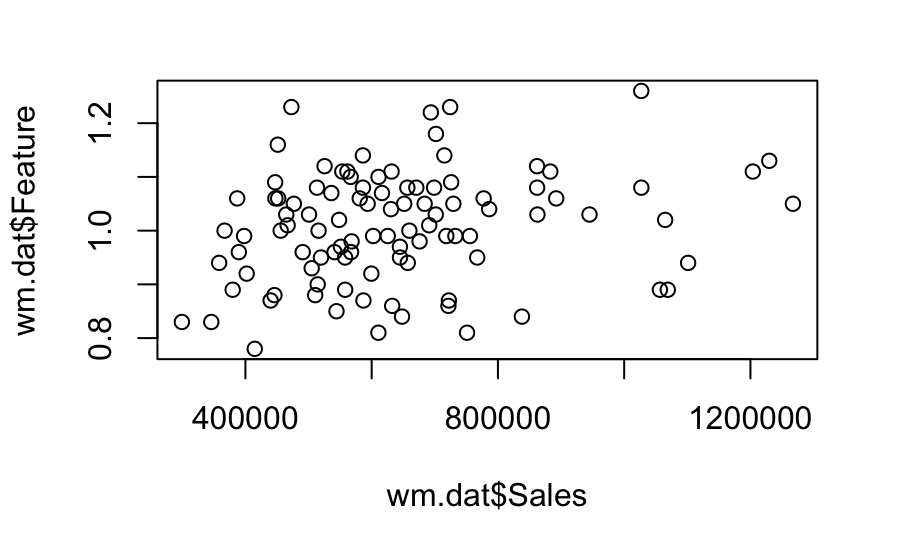

```r
plot(wm.dat$Sales,wm.dat$Feature)
```

We notice the heterogenecity here in both plots. We will consider these interactions later. Now a histogram of Sales for distribution:

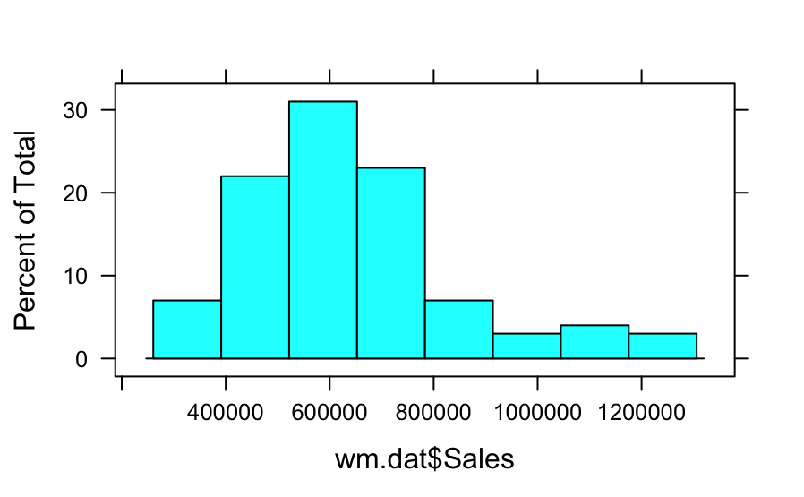

```r
histogram(wm.dat$Sales)
```

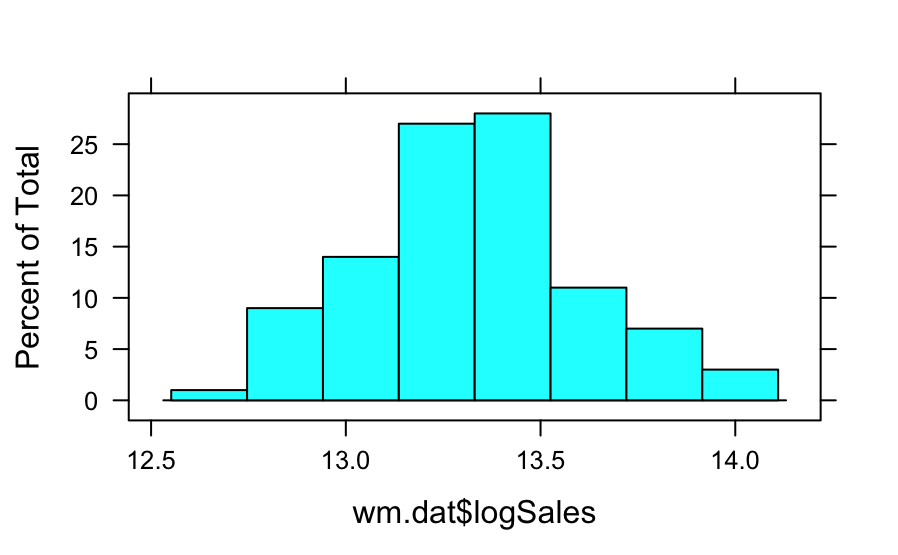

```r
histogram(wm.dat$logSales)
```

Now we will use the simplest linear model to test out:

```r
wm.lm1 = lm(logSales~Promotion+Feature+Walmart+Holiday, data=wm.dat)
summary(wm.lm1)
```

```
Call:
lm(formula = logSales ~ Promotion + Feature + Walmart + Holiday,
    data = wm.dat)

Residuals:
     Min       1Q   Median       3Q      Max
-0.45435 -0.15761 -0.00412  0.12948  0.46955

Coefficients:
               Estimate Std. Error t value Pr(>|t|)
(Intercept)    11.85276    0.28826  41.119  < 2e-16 ***
Promotion       0.84754    0.20635   4.107 8.48e-05 ***
Feature         0.75076    0.20774   3.614 0.000485 ***
WalmartPresent -0.31127    0.04233  -7.354 6.76e-11 ***
HolidayYes      0.26004    0.07765   3.349 0.001164 **
---
Signif. codes:
0 ‘***’ 0.001 ‘**’ 0.01 ‘*’ 0.05 ‘.’ 0.1 ‘ ’ 1

Residual standard error: 0.21 on 95 degrees of freedom
Multiple R-squared:  0.5206,    Adjusted R-squared:  0.5004
F-statistic: 25.79 on 4 and 95 DF,  p-value: 1.76e-14
```

The estimated coefficients correspond to lift/effect each parameter has on the log of Sales of the store (a percentage lift). The coefficient of Promotion is 0.84754, meaning when promotion is up by 1%, Sales goes up by EXP(0.84754) %.

```r
round(exp(wm.lm1$coefficients),4)
```

```
   (Intercept)      Promotion        Feature WalmartPresent
   140471.6063         2.3339         2.1186         0.7325
    HolidayYes
        1.2970
```

Similarly, when Feature goes up by 1%, Sales goes up by EXP(0.75076) %. When Warmart is in town, Sales decrease by EXP(-0.31127) %. Finally, when HolidayYes is “switched on”, meaning it is a holiday, Sales goes up by EXP(0.26004) %. All numbers are shown above.

Now we include the interactions between parameters to account for the covariance we observed earlier:

```r
wm.lm2 = lm(logSales~Promotion+Feature+Walmart+Holiday+Holiday:Walmart+Holiday:Promotion, data = wm.dat)
summary(wm.lm2)
```

```
Call:
lm(formula = logSales ~ Promotion + Feature + Walmart + Holiday +
    Holiday:Walmart + Holiday:Promotion, data = wm.dat)

Residuals:
     Min       1Q   Median       3Q      Max
-0.44745 -0.14350  0.00013  0.11836  0.47639

Coefficients:
                          Estimate Std. Error t value
(Intercept)                11.9169     0.2994  39.806
Promotion                   0.7454     0.2236   3.333
Feature                     0.7828     0.2099   3.729
WalmartPresent             -0.2978     0.0439  -6.783
HolidayYes                 -0.1128     0.7428  -0.152
WalmartPresent:HolidayYes  -0.1307     0.1887  -0.693
Promotion:HolidayYes        0.4330     0.6741   0.642
                          Pr(>|t|)
(Intercept)                < 2e-16 ***
Promotion                  0.00123 **
Feature                    0.00033 ***
WalmartPresent            1.08e-09 ***
HolidayYes                 0.87961
WalmartPresent:HolidayYes  0.49034
Promotion:HolidayYes       0.52219
---
Signif. codes:
0 ‘***’ 0.001 ‘**’ 0.01 ‘*’ 0.05 ‘.’ 0.1 ‘ ’ 1

Residual standard error: 0.2101 on 93 degrees of freedom
Multiple R-squared:  0.5302,    Adjusted R-squared:  0.4999
F-statistic: 17.49 on 6 and 93 DF,  p-value: 1.866e-13
```

```r
round(exp(wm.lm2$coefficients),4)
```

```
              (Intercept)                 Promotion
              149777.6972                    2.1073
                  Feature            WalmartPresent
                   2.1876                    0.7425
               HolidayYes WalmartPresent:HolidayYes
                   0.8933                    0.8775
     Promotion:HolidayYes
                   1.5420
```

```r
AIC(wm.lm1)
```

```
[1] -21.45434
```

```r
AIC(wm.lm2)
```

```
[1] -19.48443
```

```r
BIC(wm.lm1)
```

```
[1] -5.823324
```

```r
BIC(wm.lm2)
```

```
[1] 1.356929
```

Model comparison verdict: first model wins. Second model has too many parameters (penalized here by BIC), and some are not even significant!

Another popular model is using random effects and hierarchical linear models. They are best suited when we have repeated obversations of the same ID, e.g. customer’s all recent transactions. We will use a credit card company data.

The credit card company would like to figure out whether offering more promotions (for example, gasoline rebates and coupons for using the credit card) to their existing customers can increase the share-of-wallet of the credit card (that is, the share of a consumer’s monthly spending using the credit card in her total spending). The company would also like to figure out what customer characteristics make them more responsive to promotions. The company conducted a field experiment by randomly selecting 300 customers and offering them different monthly promotions for 12 months. The share-of-wallet data were recorded in each month for every customer. The data set also included some consumer characteristics.

```r
sow = read.csv("CreditCard_SOW_data.csv", header = T)
summary(sow)
```

```
   ConsumerID        History          Income
 Min.   :  1.00   Min.   : 6.00   Min.   : 33000
 1st Qu.: 75.75   1st Qu.:21.00   1st Qu.: 66000
 Median :150.50   Median :32.00   Median : 82000
 Mean   :150.50   Mean   :33.48   Mean   : 83847
 3rd Qu.:225.25   3rd Qu.:48.00   3rd Qu.: 98000
 Max.   :300.00   Max.   :60.00   Max.   :167000
  WalletShare       Promotion         Balance
 Min.   :0.0530   Min.   :0.0000   Min.   :   0
 1st Qu.:0.3480   1st Qu.:0.2750   1st Qu.: 583
 Median :0.4650   Median :0.6500   Median :1332
 Mean   :0.4529   Mean   :0.6167   Mean   :1538
 3rd Qu.:0.5660   3rd Qu.:0.9250   3rd Qu.:2274
 Max.   :0.7710   Max.   :1.2000   Max.   :6276
```

```r
str(sow)
```

```
'data.frame':   3600 obs. of  6 variables:
 $ ConsumerID : int  1 1 1 1 1 1 1 1 1 1 ...
 $ History    : int  55 55 55 55 55 55 55 55 55 55 ...
 $ Income     : num  82000 82000 82000 82000 82000 82000 82000 82000 82000 82000 ...
 $ WalletShare: num  0.643 0.628 0.567 0.638 0.554 0.573 0.666 0.649 0.527 0.459 ...
 $ Promotion  : num  0.5 0.2 1 0.8 0.7 1.1 0.9 0.6 0.1 0 ...
 $ Balance    : int  836 467 1208 792 1215 1248 197 567 1190 1709 ...
```

ConsumerID here should not be int., but rather a key, an ID that indicates a level.

```r
sow$ConsumerID = as.factor(sow$ConsumerID)
```

Now we add in logIncome and logSowRatio for calculus purpose.

```r
sow$logIncome = log(sow$Income)
sow$logSowRatio = log(sow$WalletShare/(1-sow$WalletShare))
str(sow)
```

```
'data.frame':   3600 obs. of  8 variables:
 $ ConsumerID : Factor w/ 300 levels "1","2","3","4",..: 1 1 1 1 1 1 1 1 1 1 ...
 $ History    : int  55 55 55 55 55 55 55 55 55 55 ...
 $ Income     : num  82000 82000 82000 82000 82000 82000 82000 82000 82000 82000 ...
 $ WalletShare: num  0.643 0.628 0.567 0.638 0.554 0.573 0.666 0.649 0.527 0.459 ...
 $ Promotion  : num  0.5 0.2 1 0.8 0.7 1.1 0.9 0.6 0.1 0 ...
 $ Balance    : int  836 467 1208 792 1215 1248 197 567 1190 1709 ...
 $ logIncome  : num  11.3 11.3 11.3 11.3 11.3 ...
 $ logSowRatio: num  0.588 0.524 0.27 0.567 0.217 ...
```

Build our first linear model:

```r
sow.lm1 = lm(logSowRatio~History+Balance+Promotion+History:Promotion+logIncome:Promotion, data = sow)
summary(sow.lm1)
```

```
Call:
lm(formula = logSowRatio ~ History + Balance + Promotion + History:Promotion +
    logIncome:Promotion, data = sow)

Residuals:
     Min       1Q   Median       3Q      Max
-0.59976 -0.14401  0.00153  0.13634  0.75883

Coefficients:
                      Estimate Std. Error  t value Pr(>|t|)
(Intercept)          8.908e-02  1.603e-02    5.558 2.92e-08
History              1.039e-02  4.153e-04   25.027  < 2e-16
Balance             -4.959e-04  2.882e-06 -172.064  < 2e-16
Promotion            7.777e-01  1.888e-01    4.120 3.87e-05
History:Promotion   -2.598e-03  5.722e-04   -4.541 5.79e-06
Promotion:logIncome -4.558e-02  1.651e-02   -2.760  0.00581

(Intercept)         ***
History             ***
Balance             ***
Promotion           ***
History:Promotion   ***
Promotion:logIncome **
---
Signif. codes:
0 ‘***’ 0.001 ‘**’ 0.01 ‘*’ 0.05 ‘.’ 0.1 ‘ ’ 1

Residual standard error: 0.2078 on 3594 degrees of freedom
Multiple R-squared:  0.8984,    Adjusted R-squared:  0.8982
F-statistic:  6353 on 5 and 3594 DF,  p-value: < 2.2e-16
```

The problem here is that this model does NOT show how each customer behaves on their individual level. We want a hierarchy to represent both the overall aggregated model AND each customer ID’s estimation. i, j here are indices. E represents unexplained residues.

logSowRatioij = β0i + β1×Balanceij + β2i×Promotionij + βij

β0i = β0 +β1×Historyi +Ei

β2i = β0 +β1×Historyi +β2×logIncomei +Ei

Here the parameters that are not indexed with i are fixed effects: History, Balance, History:Promotion, logIncome:Promotion … as opposed to those indexed with I are random effects: ConsumerID, ConsumerID:Promotion

We use a package called ‘lme4’.

```r
library(lme4)
sow.re1 = lmer(logSowRatio~History+Balance+Promotion+History:Promotion+logIncome:Promotion+(1+Promotion|ConsumerID), data = sow, REML = F, control = lmerControl(optimizer="Nelder_Mead"))
```

```
Some predictor variables are on very different scales: consider rescaling
```

```r
summary(sow.re1)
```

```
Linear mixed model fit by maximum likelihood  ['lmerMod']
Formula:
logSowRatio ~ History + Balance + Promotion + History:Promotion +
    logIncome:Promotion + (1 + Promotion | ConsumerID)
   Data: sow
Control: lmerControl(optimizer = "Nelder_Mead")

     AIC      BIC   logLik deviance df.resid
 -6532.1  -6470.2   3276.0  -6552.1     3590

Scaled residuals:
    Min      1Q  Median      3Q     Max
-3.1063 -0.6424  0.0049  0.6336  3.4532

Random effects:
 Groups     Name        Variance  Std.Dev. Corr
 ConsumerID (Intercept) 0.0359421 0.18958
            Promotion   0.0005355 0.02314  0.06
 Residual               0.0066071 0.08128
Number of obs: 3600, groups:  ConsumerID, 300

Fixed effects:
                      Estimate Std. Error  t value
(Intercept)          9.595e-02  2.655e-02    3.613
History              1.039e-02  7.135e-04   14.569
Balance             -5.003e-04  1.799e-06 -278.110
Promotion            6.129e-01  1.466e-01    4.181
History:Promotion   -2.571e-03  2.402e-04  -10.703
Promotion:logIncome -3.110e-02  1.288e-02   -2.414

Correlation of Fixed Effects:
            (Intr) Histry Balanc Promtn Hstr:P
History     -0.900
Balance     -0.107 -0.001
Promotion   -0.011  0.009  0.013
Hstry:Prmtn  0.143 -0.159 -0.002 -0.153
Prmtn:lgInc  0.001  0.000 -0.012 -0.998  0.099
fit warnings:
Some predictor variables are on very different scales: consider rescaling
```

The interpretation of the coefficients here would be: History, Promotion have a positive effect on the sow score, while Balance, History:Promotion, and Promotion:logIncome have a negative effect on the sow score. This means, the longer history the customer has with the company, the more promotion he/she receives, the more likely he/she will use the credit card. The more balance he/she has on the card, the less likely he/she will use the card - this makes sence, since credit card balance is a debt you owe the company. However, promotion might tire a customer out if it’s repeated too many time, hence History:Promotion has a negative effect on the sow score. Promotion also seems to have a negative effect when it’s couple with logIncome. This might be interpreted as higher income customers perceive promotions negatively wherreas lower income customers are more promotion-sensitive.

Now let’s look at AIC/BIC to see which model explains better.

```r
AIC(sow.lm1)
```

```
[1] -1087.389
```

```r
AIC(sow.re1)
```

```
[1] -6532.094
```

```r
BIC(sow.lm1)
```

```
[1] -1044.069
```

```r
BIC(sow.re1)
```

```
[1] -6470.207
```

Linear mixed effect is a much better model here!